# Turkiye Student Evaluation

[figure not shown]

## Abstract:

This data set contains a total 5820 evaluation scores provided by students from Gazi University in Ankara (Turkey). There is a total of 28 course specific questions and additional 5 attributes.

## Description of Dataset :

- **instr:** Instructor's identifier; values taken from {1,2,3}
- **class:** Course code (descriptor); values taken from {1-13}
- **repeat:** Number of times the student is taking this course; values taken from {0,1,2,3,...}
- **attendance:** Code of the level of attendance; values from {0, 1, 2, 3, 4}
- **difficulty:** Level of difficulty of the course as perceived by the student; values taken from {1,2,3,4,5}
- **Q1:** The semester course content, teaching method and evaluation system were provided at the start.
- **Q2:** The course aims and objectives were clearly stated at the beginning of the period.
- **Q3:** The course was worth the amount of credit assigned to it.
- **Q4:** The course was taught according to the syllabus announced on the first day of class.
- **Q5:** The class discussions, homework assignments, applications and studies were satisfactory.
- **Q6:** The textbook and other courses resources were sufficient and up to date.
- **Q7:** The course allowed field work, applications, laboratory, discussion and other studies.
- **Q8:** The quizzes, assignments, projects and exams contributed to helping the learning.
- **Q9:** I greatly enjoyed the class and was eager to actively participate during the lectures.
- **Q10:** My initial expectations about the course were met at the end of the period or year.
- **Q11:** The course was relevant and beneficial to my professional development.
- **Q12:** The course helped me look at life and the world with a new perspective.
- **Q13:** The Instructor's knowledge was relevant and up to date.
- **Q14:** The Instructor came prepared for classes.
- **Q15:** The Instructor taught in accordance with the announced lesson plan.
- **Q16:** The Instructor was committed to the course and was understandable.
- **Q17:** The Instructor arrived on time for classes.
- **Q18:** The Instructor has a smooth and easy to follow delivery/speech.
- **Q19:** The Instructor made effective use of class hours.
- **Q20:** The Instructor explained the course and was eager to be helpful to students.
- **Q21:** The Instructor demonstrated a positive approach to students.
- **Q22:** The Instructor was open and respectful of the views of students about the course.
- **Q23:** The Instructor encouraged participation in the course.
- **Q24:** The Instructor gave relevant homework assignments/projects, and helped/guided students.
- **Q25:** The Instructor responded to questions about the course inside and outside of the course.
- **Q26:** The Instructor's evaluation system (midterm and final questions, projects, assignments, etc.) effectively measured the course objectives.
- **Q27:** The Instructor provided solutions to exams and discussed them with students.
- **Q28:** The Instructor treated all students in a right and objective manner.
- **Q1-Q28** are all Likert-type, meaning that the values are taken from {1,2,3,4,5}

## Dataset Source :

http://archive.ics.uci.edu/ml/datasets/turkiye+student+evaluation

## Importing Libraries

```python
import pandas as pd
import numpy as np
import seaborn as sns
import matplotlib.pyplot as plt
%matplotlib inline
import plotly.graph_objs as go
import plotly.offline as py

import warnings
warnings.filterwarnings('ignore')
```

## Importing the Dataset

```python
data = pd.read_csv("turkiye-student-evaluation_generic.csv")
```

```python
data.head()
```

|  | instr | class | nb.repeat | attendance | difficulty | Q1 | Q2 | Q3 | Q4 | Q5 | ... | Q19 | Q20 | Q21 | Q22 | Q23 | Q24 | Q25 | Q26 | Q27 | Q28 |
| --- | --- | --- | --- | --- | --- | --- | --- | --- | --- | --- | --- | --- | --- | --- | --- | --- | --- | --- | --- | --- | --- |
| 0 | 1 | 2 | 1 | 0 | 4 | 3 | 3 | 3 | 3 | 3 | ... | 3 | 3 | 3 | 3 | 3 | 3 | 3 | 3 | 3 | 3 |
| 1 | 1 | 2 | 1 | 1 | 3 | 3 | 3 | 3 | 3 | 3 | ... | 3 | 3 | 3 | 3 | 3 | 3 | 3 | 3 | 3 | 3 |
| 2 | 1 | 2 | 1 | 2 | 4 | 5 | 5 | 5 | 5 | 5 | ... | 5 | 5 | 5 | 5 | 5 | 5 | 5 | 5 | 5 | 5 |
| 3 | 1 | 2 | 1 | 1 | 3 | 3 | 3 | 3 | 3 | 3 | ... | 3 | 3 | 3 | 3 | 3 | 3 | 3 | 3 | 3 | 3 |
| 4 | 1 | 2 | 1 | 0 | 1 | 1 | 1 | 1 | 1 | 1 | ... | 1 | 1 | 1 | 1 | 1 | 1 | 1 | 1 | 1 | 1 |

5 rows × 33 columns

```python
data.shape
```

```
(5820, 33)
```

## Summary of Data

```python
data.info()
```

```
<class 'pandas.core.frame.DataFrame'>
RangeIndex: 5820 entries, 0 to 5819
Data columns (total 33 columns):
 #   Column      Non-Null Count  Dtype
---  ------      --------------  -----
 0   instr       5820 non-null   int64
 1   class       5820 non-null   int64
 2   nb.repeat   5820 non-null   int64
 3   attendance  5820 non-null   int64
 4   difficulty  5820 non-null   int64
 5   Q1          5820 non-null   int64
 6   Q2          5820 non-null   int64
 7   Q3          5820 non-null   int64
 8   Q4          5820 non-null   int64
 9   Q5          5820 non-null   int64
```

[output cut: 25 more lines]

```python
data.describe().T
```

|  | count | mean | std | min | 25% | 50% | 75% | max |
| --- | --- | --- | --- | --- | --- | --- | --- | --- |
| instr | 5820.0 | 2.485567 | 0.718473 | 1.0 | 2.0 | 3.0 | 3.0 | 3.0 |
| class | 5820.0 | 7.276289 | 3.688175 | 1.0 | 4.0 | 7.0 | 10.0 | 13.0 |
| nb.repeat | 5820.0 | 1.214089 | 0.532376 | 1.0 | 1.0 | 1.0 | 1.0 | 3.0 |
| attendance | 5820.0 | 1.675601 | 1.474975 | 0.0 | 0.0 | 1.0 | 3.0 | 4.0 |
| difficulty | 5820.0 | 2.783505 | 1.348987 | 1.0 | 1.0 | 3.0 | 4.0 | 5.0 |
| Q1 | 5820.0 | 2.929897 | 1.341077 | 1.0 | 2.0 | 3.0 | 4.0 | 5.0 |
| Q2 | 5820.0 | 3.073883 | 1.285251 | 1.0 | 2.0 | 3.0 | 4.0 | 5.0 |
| Q3 | 5820.0 | 3.178694 | 1.253567 | 1.0 | 2.0 | 3.0 | 4.0 | 5.0 |
| Q4 | 5820.0 | 3.082474 | 1.284594 | 1.0 | 2.0 | 3.0 | 4.0 | 5.0 |
| Q5 | 5820.0 | 3.105842 | 1.278989 | 1.0 | 2.0 | 3.0 | 4.0 | 5.0 |
| Q6 | 5820.0 | 3.107388 | 1.280807 | 1.0 | 2.0 | 3.0 | 4.0 | 5.0 |
| Q7 | 5820.0 | 3.066323 | 1.279097 | 1.0 | 2.0 | 3.0 | 4.0 | 5.0 |
| Q8 | 5820.0 | 3.041924 | 1.283481 | 1.0 | 2.0 | 3.0 | 4.0 | 5.0 |
| Q9 | 5820.0 | 3.165979 | 1.268930 | 1.0 | 2.0 | 3.0 | 4.0 | 5.0 |
| Q10 | 5820.0 | 3.090722 | 1.275309 | 1.0 | 2.0 | 3.0 | 4.0 | 5.0 |
| Q11 | 5820.0 | 3.183849 | 1.295443 | 1.0 | 2.0 | 3.0 | 4.0 | 5.0 |
| Q12 | 5820.0 | 3.035567 | 1.305772 | 1.0 | 2.0 | 3.0 | 4.0 | 5.0 |
| Q13 | 5820.0 | 3.242784 | 1.264201 | 1.0 | 2.0 | 3.0 | 4.0 | 5.0 |
| Q14 | 5820.0 | 3.290893 | 1.255373 | 1.0 | 3.0 | 3.0 | 4.0 | 5.0 |
| Q15 | 5820.0 | 3.287285 | 1.253122 | 1.0 | 3.0 | 3.0 | 4.0 | 5.0 |
| Q16 | 5820.0 | 3.169588 | 1.288015 | 1.0 | 2.0 | 3.0 | 4.0 | 5.0 |
| Q17 | 5820.0 | 3.398454 | 1.267530 | 1.0 | 3.0 | 4.0 | 4.0 | 5.0 |
| Q18 | 5820.0 | 3.222509 | 1.279799 | 1.0 | 2.0 | 3.0 | 4.0 | 5.0 |
| Q19 | 5820.0 | 3.261684 | 1.268442 | 1.0 | 3.0 | 3.0 | 4.0 | 5.0 |
| Q20 | 5820.0 | 3.285395 | 1.276848 | 1.0 | 3.0 | 3.0 | 4.0 | 5.0 |
| Q21 | 5820.0 | 3.307388 | 1.269974 | 1.0 | 3.0 | 3.0 | 4.0 | 5.0 |
| Q22 | 5820.0 | 3.317526 | 1.268358 | 1.0 | 3.0 | 3.0 | 4.0 | 5.0 |
| Q23 | 5820.0 | 3.201890 | 1.272590 | 1.0 | 2.0 | 3.0 | 4.0 | 5.0 |
| Q24 | 5820.0 | 3.166838 | 1.275909 | 1.0 | 2.0 | 3.0 | 4.0 | 5.0 |
| Q25 | 5820.0 | 3.312543 | 1.257286 | 1.0 | 3.0 | 3.0 | 4.0 | 5.0 |
| Q26 | 5820.0 | 3.222165 | 1.270695 | 1.0 | 2.0 | 3.0 | 4.0 | 5.0 |
| Q27 | 5820.0 | 3.154811 | 1.291872 | 1.0 | 2.0 | 3.0 | 4.0 | 5.0 |
| Q28 | 5820.0 | 3.308076 | 1.278709 | 1.0 | 3.0 | 3.0 | 4.0 | 5.0 |

## Total Missing Values

```python
data.isnull().sum()
```

```
instr         0
class         0
nb.repeat     0
attendance    0
difficulty    0
Q1            0
Q2            0
Q3            0
Q4            0
Q5            0
Q6            0
Q7            0
Q8            0
Q9            0
Q10           0
Q11           0
Q12           0
Q13           0
Q14           0
Q15           0
Q16           0
Q17           0
Q18           0
Q19           0
Q20           0
Q21           0
Q22           0
Q23           0
Q24           0
Q25           0
Q26           0
Q27           0
Q28           0
dtype: int64
```

- NO missing values

## Exploratory Data Analysis

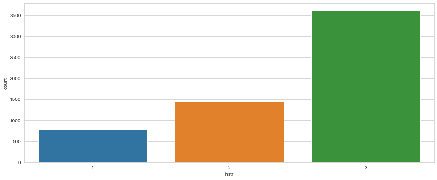

```python
sns.set_style("whitegrid")
plt.figure(figsize = (15, 6))
sns.countplot(data["instr"])
```

- Most student taught by the third Instructor, but this don’t necessarily mean he taught most of the classes.
- There could be a large gap of the number of students between each classes

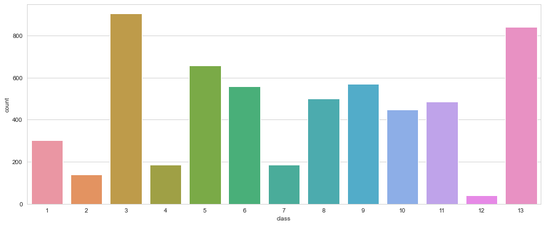

```python
plt.figure(figsize = (15, 6))
sns.countplot(data["class"])
```

- The number of responses of some classes is clearly much lower compared to the rest.
- Doing a little bit more analysis, we could see that the 3rd instructor taught 7 classes : class no 3, 4, 5, 8, 9, 12, and 13.

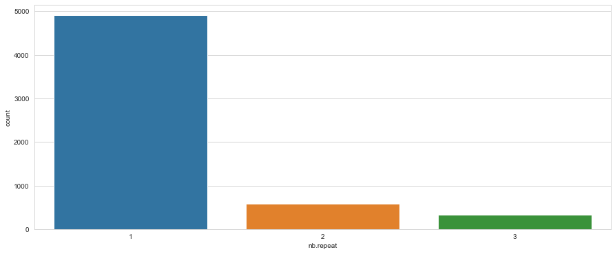

```python
plt.figure(figsize = (15, 6))
sns.countplot(data["nb.repeat"])
```

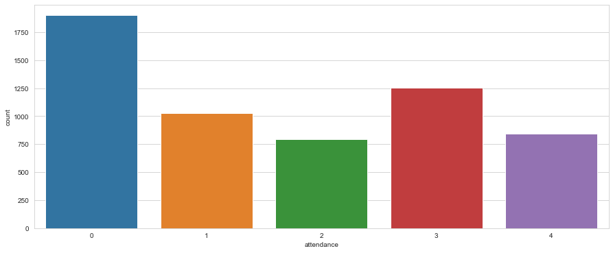

```python
plt.figure(figsize = (15, 6))
sns.countplot(data["attendance"])
```

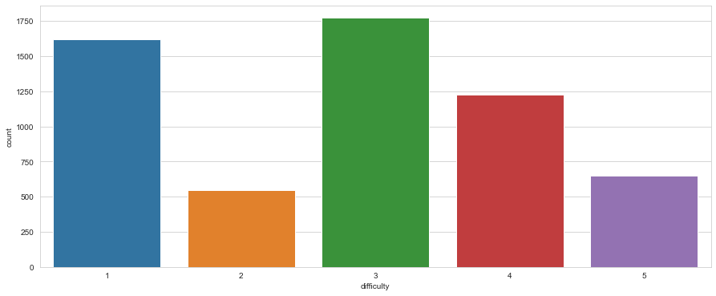

```python
plt.figure(figsize = (15, 6))
sns.countplot(data["difficulty"])
```

**The series of questions answered by the students.**

**There are 28 questions, each answered from 1 (very bad) to 5 (very good).**

```python
x_questions = data.iloc[:, 5:33]
q_mean = x_questions.mean(axis = 0)
total_mean = q_mean.mean()
```

```python
q_mean = q_mean.to_frame('mean')
q_mean.reset_index(level = 0, inplace = True)
q_mean.head()
```

|  | index | mean |
| --- | --- | --- |
| 0 | Q1 | 2.929897 |
| 1 | Q2 | 3.073883 |
| 2 | Q3 | 3.178694 |
| 3 | Q4 | 3.082474 |
| 4 | Q5 | 3.105842 |

```python
total_mean
```

```
3.1861561119293085
```

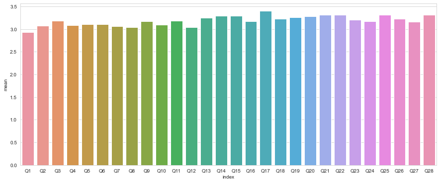

```python
plt.figure(figsize = (15,6))
sns.barplot(x = 'index', y = 'mean', data = q_mean)
```

- The mean of each question tend to be around the middle value (3).
- Looking at the graph above, the standard deviation should be small.
- Let’s do a quick check to be sure :

```python
std_by_questions = q_mean.std()
std_by_questions
```

```
mean    0.109106
dtype: float64
```

- The standard deviation is 0.109106, which is reasonably small and inline with above graph.
- This mean that the quality of each class is more or less the same according to the survey answers.

## Correlation Matrix

### Heat map

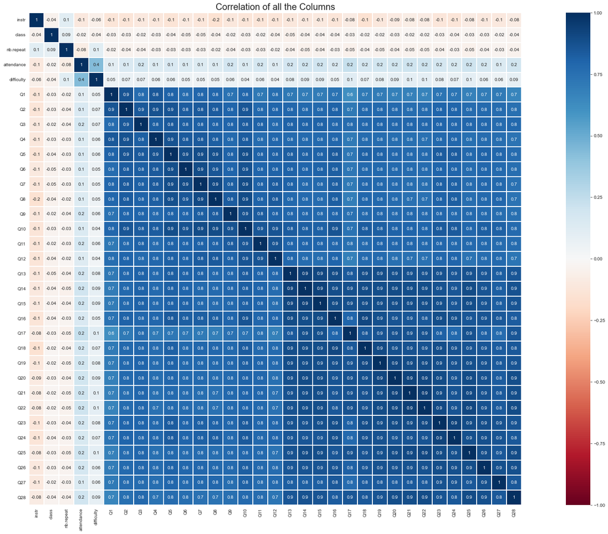

```python
plt.figure(figsize = (35,20))
plt.title('Correlation of all the Columns', fontsize = 20)
sns.heatmap(data.corr(), annot = True, vmin = -1, vmax = 1, center = 0, fmt = '.1g', linewidths = 1, linecolor = 'white',
            square = True, cmap ='RdBu')
```

## Data Preparation

- We are lucky that the Q1-Q28 features are Likert-type, which are scaled from 1–5.
- Hence, the only thing we can fit them to our models directly.
- Let’s remove all non-question features because we will group the student based on their answer in the survey

```python
X = data.iloc[:,5:33]
```

- Remember that we don't know how many clusters will be present in this data or whether the clusters created by our model will be "natural" or not, so we'll need to check it using visualisation.
- However, there will be 28 features in a 28-dimensional space. Because it will be difficult for humans to perceive (and comprehend) such a large number of dimensions, people commonly utilise dimensionality reduction methods to reduce them to 2 dimensional space (x, y).

### Principal Component Analysis (PCA)

```python
from sklearn.decomposition import PCA
pca = PCA(n_components = 2, random_state = 42)
X_pca = pca.fit_transform(X)
```

```python
X_pca
```

```
array([[ 0.98901533,  0.52279815],
       [ 0.98901533,  0.52279815],
       [-9.59128851,  0.6408021 ],
       ...,
       [-9.59128851,  0.6408021 ],
       [11.56931918,  0.40479421],
       [11.56931918,  0.40479421]])
```

### Amount of variance we preserved from the original data

```python
pca.explained_variance_ratio_.cumsum()[1]
```

```
0.8671381678891082
```

## Model Training

### K-Means

```python
from sklearn.cluster import KMeans
distortions = []
cluster_range = range(1,6)

# elbow method
for i in cluster_range:
    model = KMeans(n_clusters = i, init = 'k-means++', n_jobs = -1, random_state = 42)
    model.fit(X_pca)
    distortions.append(model.inertia_)
```

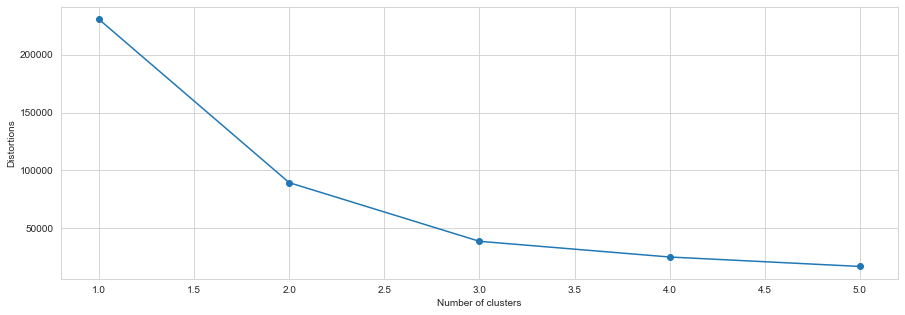

```python
plt.figure(figsize = (15,5))
plt.plot(cluster_range, distortions, marker = 'o')
plt.xlabel("Number of clusters")
plt.ylabel('Distortions')
plt.show()
```

### K-Means with 3 clusters

```python
model = KMeans(n_clusters = 3, init = 'k-means++', n_jobs = -1, random_state = 42)
model.fit(X_pca)
y = model.predict(X_pca)
```

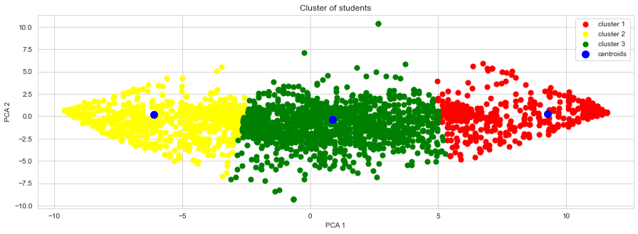

```python
plt.figure(figsize = (15,5))
plt.scatter(X_pca[y == 0, 0], X_pca[y == 0, 1], s = 50, c = 'red',    label = 'cluster 1')
plt.scatter(X_pca[y == 1, 0], X_pca[y == 1, 1], s = 50, c = 'yellow', label = 'cluster 2')
plt.scatter(X_pca[y == 2, 0], X_pca[y == 2, 1], s = 50, c = 'green',  label = 'cluster 3')
plt.scatter(model.cluster_centers_[:,0], model.cluster_centers_[:, 1], s = 100, c = 'blue', label = 'centroids')
plt.title('Cluster of students')
plt.xlabel('PCA 1')
plt.ylabel('PCA 2')
plt.legend()
plt.show()
```

- We could see that the observations are tightly grouped (this confirmed our analysis in the Data Exploration earlier) and the clusters are reasonably **“natural”.**

```python
from collections import Counter
Counter(y)
```

```
Counter({2: 2358, 1: 2222, 0: 1240})
```

```python
model = KMeans(n_clusters = 3, init = 'k-means++', n_jobs = -1, random_state = 42)
model.fit(X)
y = model.predict(X)
```

```python
Counter(y)
```

```
Counter({0: 2358, 2: 2223, 1: 1239})
```

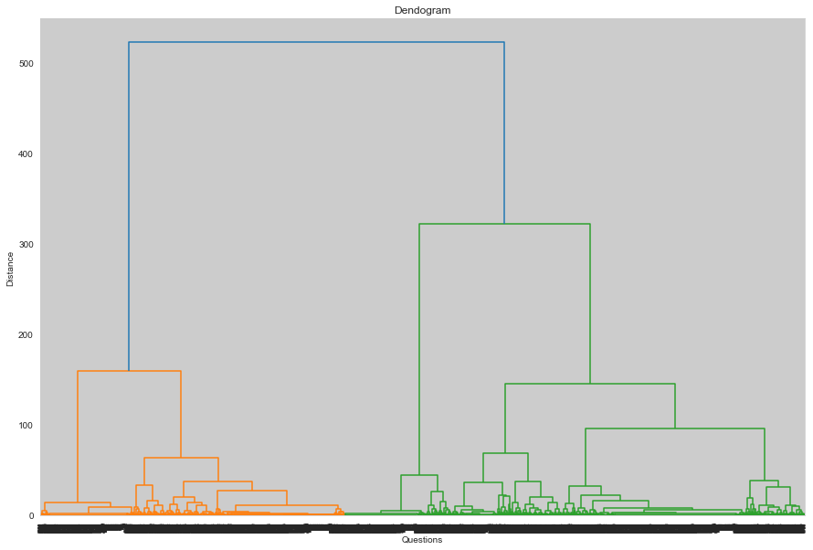

```python
import scipy.cluster.hierarchy as hier
plt.figure(figsize = (15,10))
dendogram = hier.dendrogram(hier.linkage(X_pca, method = 'ward'))
plt.title('Dendogram')
plt.xlabel("Questions")
plt.ylabel("Distance")
plt.show()
```

```python
from sklearn.cluster import AgglomerativeClustering
model = AgglomerativeClustering(n_clusters = 2, affinity = 'euclidean', linkage = 'ward')
y = model.fit_predict(X_pca)
```

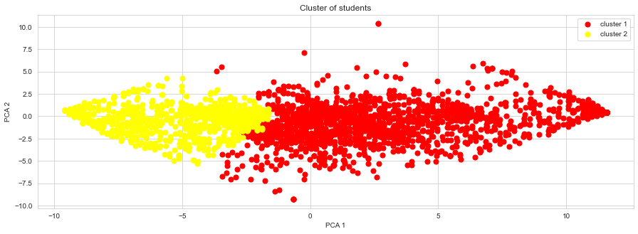

```python
plt.figure(figsize = (15,5))
plt.scatter(X_pca[y == 0, 0], X_pca[y == 0, 1], s = 50, c = 'red',    label = 'cluster 1')
plt.scatter(X_pca[y == 1, 0], X_pca[y == 1, 1], s = 50, c = 'yellow', label = 'cluster 2')
plt.title('Cluster of students')
plt.xlabel('PCA 1')
plt.ylabel('PCA 2')
plt.legend()
plt.show()
```

```python
Counter(y)
```

```
Counter({0: 3502, 1: 2318})
```

- Around 60% students belong to the first cluster.

## Conclusion

Prefering the result of K-Means with k = 3 from Elbow method because having three different groups seems to be more meaningful (**Dissatisfied**, **Neutral**, and **Satisfied**).

Smaller number of clusters (**Dissatisfied/Neutral** & **Satisfied**) from the Ward’s linkage lead to a larger gap between the mean of each cluster.

Ultimately, the decision whether to have two or three clusters of students depend on the business decision.